# Exploratory analysis of treatise metadata

Lincoln Mullen

## What is in the corpus?

The simplest way to find out what is in the corpus is to look at the subject headings which have been assigned to the items. There are two kinds of subject headings, Library of Congress subject terms, and terms which must have been assigned by Gale. The terms assigned by Gale appear to be much less specific. But we will compare the two to get a sense of the main subject matter in the corpus.

### MoML categories

```r
us_subjects_moml %>%
  count(subject) %>%
  arrange(desc(n)) %>%
  mutate(percent = round(n / nrow(us_items) * 100, 1),
         subject = str_trunc(subject, 40))
```

| subject | n | percent |
| --- | --- | --- |
| Procedural Law | 1842 | 13.6 |
| Constitutional Law | 935 | 6.9 |
| General Studies | 911 | 6.7 |
| Biography | 864 | 6.4 |
| Criminal Law | 823 | 6.1 |
| Real Property | 679 | 5.0 |
| Taxation and Public Finance | 583 | 4.3 |
| Politics & Government | 538 | 4.0 |
| Business Associations | 524 | 3.9 |
| Administration of Justice and Adminis... | 519 | 3.8 |

[output cut: 106 more lines]

There are 116 unique MoML categories.

These categories are quite useful, since they correspond to the current categorization of the law. However, if we are interested in how the categorization of the law changed over time, then perhaps we will need better categories.

These are the legal history titles.

```r
us_subjects_moml %>%
  filter(subject == "Legal History") %>%
  left_join(us_items, by = "document_id") %>%
  filter(!is.na(title_full)) %>%
  transmute(title = str_trunc(title_full, 80))
```

| title |
| --- |
| De l'esclavage dans ses rapports avec l'union américaine. |
| "Imperialism" and "the tracks of our forefathers" : a paper. |
| The law of civilization and decay : an essay on history. |
| The Ordinance of 1787 : a reply. |
| An inquiry into the law of Negro slavery in the United States of America : to... |
| The Constitution, jurisdiction and practice of the courts of Pennsylvania in ... |
| The colonial executive prior to the restoration. |
| The Genesee tract : cessions between New York and Massachusetts, the Phelps a... |
| An essay on the growth of law. |
| The bi-centennial of the purchase of East New Jersey by the proprietors. |

[output cut: 127 more lines]

These are the collected essay titles:

```r
us_subjects_moml %>%
  filter(subject == "Collected Essays") %>%
  left_join(us_items, by = "document_id") %>%
  transmute(title_display = str_trunc(title_display, 80))
```

| title_display |
| --- |
| Addresses and orations of Rufus Choate |
| Select speeches of John Sergeant of Pennsylvania |
| Sundry speeches and writings of William C. De Witt : driftwood from out the c... |
| Sundry speeches and writings of William C. De Witt : driftwood from out the c... |
| The forensic speeches of David Paul Brown : selected from important trials an... |
| Speeches and addresses. |
| Charles Devens : orations and addresses on various occasions, civil and milit... |
| The divorce problem : a study in statistics. |
| Facts as to divorce in New England. |
| The family in the history of Christianity. |

[output cut: 316 more lines]

We are probably justified in excluding at least those three categories as not really being treatises in any sense of the term.

### LoC categories

We can also see what is in the Library of Congress categories.

```r
us_subjects_loc %>%
  count(subject) %>%
  arrange(desc(n)) %>%
  mutate(percent = round(n / nrow(us_items) * 100, 1),
         subject = str_trunc(subject, 40))
```

| subject | n | percent |
| --- | --- | --- |
| Law -- United States | 262 | 1.9 |
| Evidence (Law) -- United States | 226 | 1.7 |
| Corporation law -- United States | 217 | 1.6 |
| United States -- Politics and government | 177 | 1.3 |
| Courts -- United States | 164 | 1.2 |
| United States -- Constitutional law | 160 | 1.2 |
| Contracts -- United States | 159 | 1.2 |
| Real property -- United States | 157 | 1.2 |
| Forms (Law) -- United States | 156 | 1.1 |
| Civil procedure -- United States | 151 | 1.1 |

[output cut: 990 more lines]

There are far more Library of Congress categories: 8,901 unique categories. And the biggest categories have a much smaller percentages of items than the MoML.

### Exclude unwanted categories

We want to exclude the categories which are biographical or otherwise unlikely to be actual treatises. We do that by getting a list of an items which *are* biographical or so on, and then removing them from the main list of items.

```r
excluded_categories <- c("Biography", "Legal History", "Collected Essays")
to_exclude <- us_subjects_moml %>%
  filter(subject %in% excluded_categories)
us_items <- anti_join(us_items, to_exclude, by = "document_id")
```

## Publication history

Now we can look into the publication history of treatises.

### How long

We can do a simple histogram to get a sense of how long these treatises are.

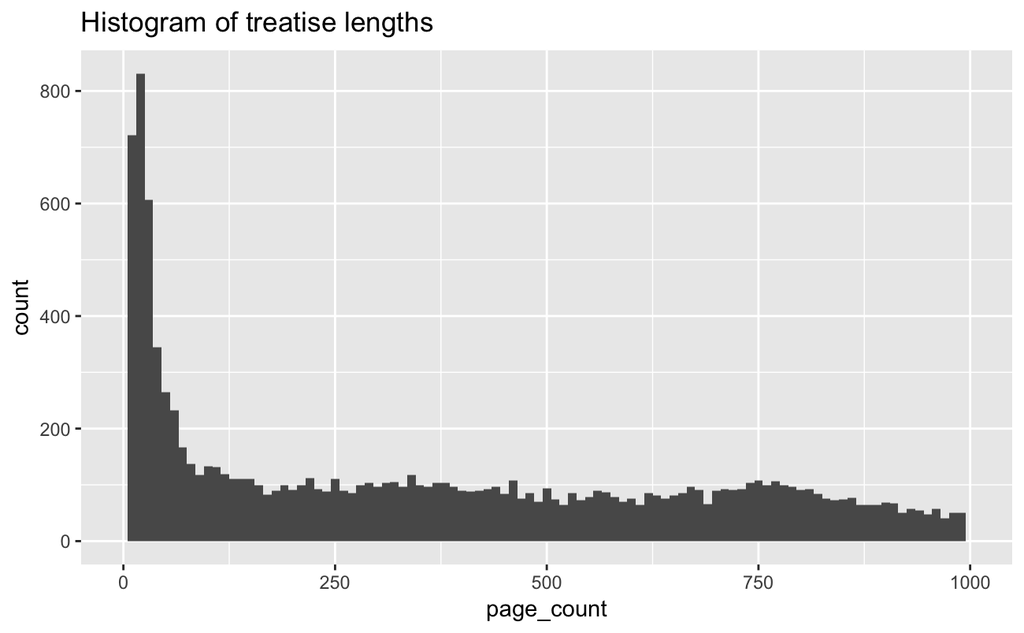

```r
us_items %>%
  ggplot(aes(page_count)) +
  geom_histogram(binwidth = 10) +
  xlim(0, 1000) +
  labs(title = "Histogram of treatise lengths")
```

Some of these items are obviously not treatises, given that they are only a few pages long. We should exclude all items below a certain threshold. For now this is somewhat arbitrary, but we might be able to find a reasonable figure.

```r
us_items <- us_items %>%
  filter(page_count > 50)
```

### When

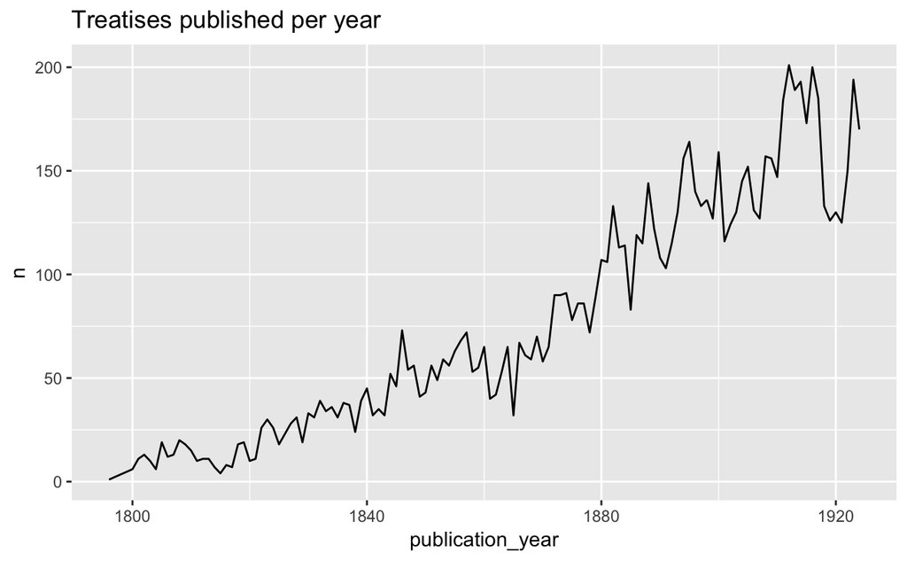

```r
publications_per_year <- us_items %>%
  count(publication_year) %>%
  arrange(desc(publication_year))
ggplot(publications_per_year, aes(x = publication_year, y = n)) +
  geom_line() +
  labs(title = "Treatises published per year")
```

### Where

We can also ask which cities were most frequently publication places.

```r
items_per_city <- us_items %>%
  mutate(city = fct_lump(city, n = 30)) %>%
  count(city) %>%
  mutate(percent = round(n / sum(n) * 100, 1)) %>%
  arrange(desc(n))
items_per_city
```

| city | n | percent |
| --- | --- | --- |
| New York | 2100 | 22.0 |
| Boston | 1546 | 16.2 |
| Other | 1165 | 12.2 |
| Philadelphia | 997 | 10.4 |
| Chicago | 802 | 8.4 |
| Albany | 444 | 4.6 |
| Washington | 328 | 3.4 |
| St Paul | 278 | 2.9 |
| San Francisco | 277 | 2.9 |
| Cincinnati | 221 | 2.3 |

[output cut: 22 more lines]

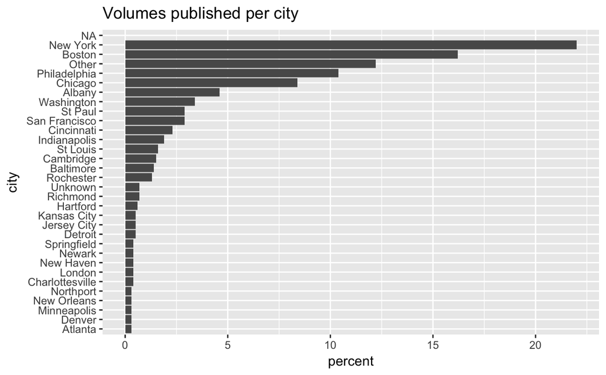

```r
ggplot(items_per_city, aes(x = fct_reorder(city, percent), y = percent)) +
  geom_bar(stat = "identity") +
  coord_flip() +
  labs(x = "city",
       title = "Volumes published per city")
```

Unsurprisingly New York is the most common publication city. But there are also many other cities which are represented, which makes sense if those treatises cover state topics. So that is a question for further investigation.

## Combining variables

We can make some of the charts above better by showing how they change over time.

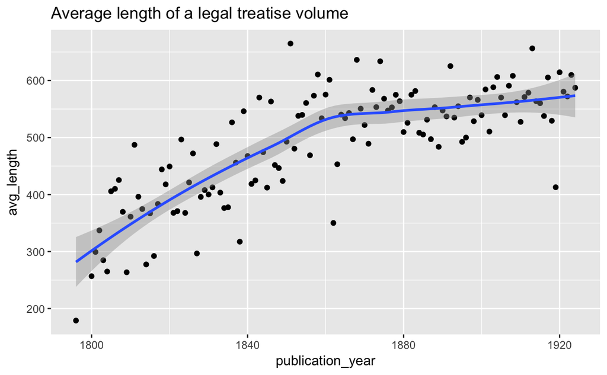

```r
us_items %>%
  group_by(publication_year) %>%
  summarize(avg_length = mean(page_count)) %>%
  ggplot(aes(publication_year, avg_length)) +
  geom_point() +
  geom_smooth(method = "loess") +
  labs(title = "Average length of a legal treatise volume")
```

Note that we are dealing with volumes, not titles. So we would have to first calculate the total per title.

### Changing subjects over time

Using the MOML subjects, let’s see how the most common subjects changed over time.

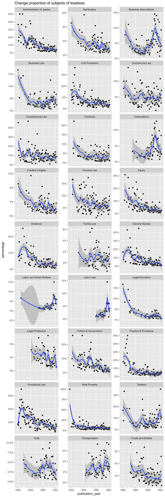

```r
subjects_lumped <- us_subjects_moml %>%
  mutate(subject = fct_lump(subject, n = 32),
         subject = fct_recode(subject,
            "Administration of Justice" = "Administration of Justice and Administrative Law",
            "Constitutional Law" = "Constitutional Law: Special Topics",
            "Taxation" = "Taxation and Public Finance"))
us_items %>%
  left_join(subjects_lumped, by = "document_id") %>%
  count(publication_year, subject) %>%
  rename(n_with_subject = n) %>%
  left_join(publications_per_year, by = "publication_year") %>%
  rename(total_published = n) %>%
  mutate(percentage = n_with_subject / total_published) %>%
  filter(subject != "Other") %>%
  ggplot(aes(x = publication_year, y = percentage)) +
  geom_point() + geom_smooth(span = 0.3, method = "loess") +
  facet_wrap(~subject, ncol = 3, scales = "free_y") +
  labs(title = "Change proportion of subjects of treatises") +
  scale_y_continuous(labels = scales::percent)
```

Note that the y-scale is not fixed.